# Tibbles, with solutions (ds4psy)

Hansjörg Neth, SPDS, uni.kn

2019 05 28

# Introduction

This file contains **essential commands** from [Chapter 10: Tibbles](https://r4ds.had.co.nz/tibbles.html) of the textbook [r4ds](http://r4ds.had.co.nz) and corresponding examples and exercises. A command is considered “essential” when you really need to *know* it and need to know *how to use* it to succeed in this course.

All [ds4psy](http://rpository.com/ds4psy/) essentials so far:

| Nr. | Topic |
| --- | --- |
| 0. | [Syllabus](http://rpository.com/ds4psy/) |
| 1. | [Basic R concepts and commands](http://rpository.com/ds4psy/essentials/basics.html) |
| 2. | [Visualizing data](http://rpository.com/ds4psy/essentials/visualize.html) |
| 3. | [Transforming data](http://rpository.com/ds4psy/essentials/transform.html) |
| 4. | [Exploring data (EDA)](http://rpository.com/ds4psy/essentials/explore.html) |
| 5. | **Tibbles** [*](http://rpository.com/ds4psy/essentials/tibbles.html) |
| 6. | [Importing data](http://rpository.com/ds4psy/essentials/import.html) |
| 7. | [Tidying data](http://rpository.com/ds4psy/essentials/tidy.html) |
| 8. | [Joining data](http://rpository.com/ds4psy/essentials/join.html) |
| 9. | [Functions](http://rpository.com/ds4psy/essentials/function.html) |
| 10. | [Iteration](http://rpository.com/ds4psy/essentials/iteration.html) |
| +. | [Datasets](http://rpository.com/ds4psy/essentials/datasets.html) |

## Course coordinates

[figure not shown]

- PSY-15150, at the [University of Konstanz](https://www.uni-konstanz.de/) by [Hansjörg Neth](http://neth.de/) (h.neth@uni.kn, [SPDS](https://www.spds.uni-konstanz.de/), office D507).
- Summer 2019: Mondays, 15:15–16:45, D435.
- Links to current [course syllabus](http://rpository.com/ds4psy/) | [ZeUS](https://zeus.uni-konstanz.de:443/hioserver/pages/startFlow.xhtml?_flowId=detailView-flow&unitId=5101&periodId=179&navigationPosition=hisinoneLehrorganisation,examEventOverviewOwn) | [Ilias](https://ilias.uni-konstanz.de/ilias/goto_ilias_uni_crs_863036.html)
- [ds4psy](https://bookdown.org/hneth/ds4psy/%3E) essentials and WPAs

## Preparations

Create an R script (`.R`) or an R-Markdown file (`.Rmd`) and load the R packages of the `tidyverse`. (**Hint:** Structure your script by inserting spaces, meaningful comments, and sections.)

```r
## Tibbles | ds4psy
## 2019 05 20
## ----------------------------

## Preparations: ----------

library(tidyverse)

## 1. Topic: ----------

# etc.

## End of file (eof). ----------
```

To use [R Markdown](https://rmarkdown.rstudio.com), create a corresponding file and save it with the `.Rmd` extension (e.g., by selecting `File > New File > R Markdown`). For instructions on combining text and code, see [Chapter 27: R Markdown](https://r4ds.had.co.nz/r-markdown.html) of our textbook, or use one of the following templates:

- minimal template: `rmd_template_s` [in .Rmd | .html format]
- medium template: `rmd_template_m` [in .Rmd | .html format]
- explicit explanations: `Rmarkdown_basics` [in .Rmd | .html format]

**Hint:** Try to *knit* your `.Rmd` file immediately after saving it and marvel at the beauty of the resulting `.html`-file. If this works, keep doing this routinely from now on, putting all your R-code into code chunks, and any text (like headings or conclusions) that describes or explains what you are doing outside of them. From now on, you can share your `.html` output files, rather than your `.Rmd` source files when showing off your R and data science skills.

# Tibbles

Whenever working with rectangular data structures – data consisting of multiple cases (rows) and variables (columns) – our first step is to create or transform the data into a *tibble* (i.e., a simple version of a *data frame*).

## Creating tibbles

### Basic commands

There are 3 basic commands for creating tibbles:

1. `as_tibble` converts (or coerces) an existing *rectangle* of data (e.g., a data frame) into a tibble.
2. `tibble` converts several *vectors* into (the columns of) a tibble.
3. `tribble` converts a *table* (entered row-by-row) into a tibble.

#### Check

The 3 commands yield the same type of output (i.e., a tibble), but require different inputs. Ask yourself which kind of input each command takes and how this input needs to be structured and formatted (e.g., with parentheses, commas, etc.).

### 1. `as_tibble` (rectangles)

Use `as_tibble` when the data to be used is already in rectangular format (e.g., the rows and columns of a data frame or a matrix):

1. From an exisiting data frame:

```r
## Using the data frame `sleep`: ------

# ?datasets::sleep # provides background information on the data set.

# Save the sleep data frame (as df):
df <- datasets::sleep

# Convert df into a tibble (tb):
tb <- as_tibble(df)

# Inspect the data frame df: ----
dim(df)
```

```
#> [1] 20  3
```

```r
is.data.frame(df)
```

```
#> [1] TRUE
```

```r
head(df)
```

```
#>   extra group ID
#> 1   0.7     1  1
#> 2  -1.6     1  2
#> 3  -0.2     1  3
#> 4  -1.2     1  4
#> 5  -0.1     1  5
#> 6   3.4     1  6
```

```r
str(df)
```

```
#> 'data.frame':    20 obs. of  3 variables:
#>  $ extra: num  0.7 -1.6 -0.2 -1.2 -0.1 3.4 3.7 0.8 0 2 ...
#>  $ group: Factor w/ 2 levels "1","2": 1 1 1 1 1 1 1 1 1 1 ...
#>  $ ID   : Factor w/ 10 levels "1","2","3","4",..: 1 2 3 4 5 6 7 8 9 10 ...
```

```r
# Inspect the tibble tb: ----
dim(tb)
```

```
#> [1] 20  3
```

```r
is.tibble(tb)
```

```
#> [1] TRUE
```

```r
is.data.frame(tb)  # => tibbles ARE data frames.
```

```
#> [1] TRUE
```

```r
tb
```

```
#> # A tibble: 20 x 3
#>    extra group ID
#>    <dbl> <fct> <fct>
#>  1   0.7 1     1
#>  2  -1.6 1     2
#>  3  -0.2 1     3
#>  4  -1.2 1     4
#>  5  -0.1 1     5
#>  6   3.4 1     6
#>  7   3.7 1     7
#>  8   0.8 1     8
#>  9   0   1     9
#> 10   2   1     10
#> 11   1.9 2     1
#> 12   0.8 2     2
#> 13   1.1 2     3
#> 14   0.1 2     4
#> 15  -0.1 2     5
#> 16   4.4 2     6
#> 17   5.5 2     7
#> 18   1.6 2     8
#> 19   4.6 2     9
#> 20   3.4 2     10
```

```r
head(tb)
```

```
#> # A tibble: 6 x 3
#>   extra group ID
#>   <dbl> <fct> <fct>
#> 1   0.7 1     1
#> 2  -1.6 1     2
#> 3  -0.2 1     3
#> 4  -1.2 1     4
#> 5  -0.1 1     5
#> 6   3.4 1     6
```

```r
glimpse(tb)
```

```
#> Observations: 20
#> Variables: 3
#> $ extra <dbl> 0.7, -1.6, -0.2, -1.2, -0.1, 3.4, 3.7, 0.8, 0.0, 2.0, 1....
#> $ group <fct> 1, 1, 1, 1, 1, 1, 1, 1, 1, 1, 2, 2, 2, 2, 2, 2, 2, 2, 2, 2
#> $ ID    <fct> 1, 2, 3, 4, 5, 6, 7, 8, 9, 10, 1, 2, 3, 4, 5, 6, 7, 8, 9...
```

2. From an existing matrix:

```r
## Coercing a matrix into a tibble: ------
mx <- matrix(rnorm(n = 20, mean = 100, sd = 10), nrow = 5, ncol = 4)  # create a matrix (of random numbers)

# Convert mx into a tibble:
t2 <- as_tibble(mx)
t2
```

```
#> # A tibble: 5 x 4
#>      V1    V2    V3    V4
#>   <dbl> <dbl> <dbl> <dbl>
#> 1  91.1 106.  102.   101.
#> 2 104.  102.   91.9  109.
#> 3 114.  110.   93.6  105.
#> 4  90.1 130.   97.5  118.
#> 5  96.4  96.5  96.5  107.
```

```r
names(t2)  # variables have been named (by default)
```

```
#> [1] "V1" "V2" "V3" "V4"
```

#### Practice

Convert some other R datasets (e.g., `datasets::attitude`, `datasets::mtcars`, and `datasets::Orange`) into tibbles and inspect their dimensions and contents.

- What types of *variables* (columns) do they contain?
- What is the basic unit of an *observation* (row)?

### 2. `tibble` (columns)

Use `tibble` when the data to be used appears as a collection of columns. For instance, imagine we have the following information about a family:

**Table 1:** Example data of some family.

| id | name | age | gender | drives | married_2 |
| --- | --- | --- | --- | --- | --- |
| 1 | Adam | 46 | male | TRUE | Eva |
| 2 | Eva | 48 | female | TRUE | Adam |
| 3 | Xaxi | 21 | female | FALSE | Zenon |
| 4 | Yota | 19 | female | TRUE | NA |
| 5 | Zack | 17 | male | FALSE | NA |

One way of viewing this table is as a series of columns. Each column consists of a variable name and the same number of (here: 5) values, which can be of different types (here: numbers, characters, or Boolean truth values). Each column may or may not contain missing values (entered as `NA`).

The `tibble` command expects that each column of the table is entered as a vector:

```r
## Create a tibble from vectors (column-by-column):
fm <- tibble(
  id       = c(1, 2, 3, 4, 5), # OR: id = 1:5,
  name     = c("Adam", "Eva", "Xaxi", "Yota", "Zack"),
  age      = c(46, 48, 21, 19, 17),
  gender   = c("male", rep("female", 3), "male"),
  drives   = c(TRUE, TRUE, FALSE, TRUE, FALSE),
  married_2 = c("Eva", "Adam", "Zenon", NA, NA)
  )

fm  # prints the tibble:
```

```
#> # A tibble: 5 x 6
#>      id name    age gender drives married_2
#>   <dbl> <chr> <dbl> <chr>  <lgl>  <chr>
#> 1     1 Adam     46 male   TRUE   Eva
#> 2     2 Eva      48 female TRUE   Adam
#> 3     3 Xaxi     21 female FALSE  Zenon
#> 4     4 Yota     19 female TRUE   <NA>
#> 5     5 Zack     17 male   FALSE  <NA>
```

Note some **details**:

- Each vector is labeled by the variable (column) name, which is *not* put into quotes;
- Avoid spaces within variable (column) names (or enclose names in single quotes if you really `must use spaces`);
- All vectors need to have the same length;
- Each vector is of a single type (numeric, character, or Boolean truth values);
- Consecutive vectors are separated by commas (but there is no comma after the final vector).

When using `tibble`, later vectors may use the values of earlier vectors:

```r
# Using earlier vectors when defining later ones:
abc <- tibble(
  ltr  = LETTERS[1:5],
  n    = 1:5,
  l_n  = paste(ltr, n, sep = "_"),  # combining abc with num
  n_sq = n^2                        # squaring num
  )

abc  # prints the tibble:
```

```
#> # A tibble: 5 x 4
#>   ltr       n l_n    n_sq
#>   <chr> <int> <chr> <dbl>
#> 1 A         1 A_1       1
#> 2 B         2 B_2       4
#> 3 C         3 C_3       9
#> 4 D         4 D_4      16
#> 5 E         5 E_5      25
```

#### Practice

Find some tabular data online (e.g., on [Wikipedia](https://en.wikipedia.org)) and enter it as a tibble.

### 3. `tribble` (rows)

Use `tribble` when the data to be used appears as a collection of rows (or already is in tabular form).

For instance, when you copy and paste the above family data from an electronic document, it is easy to insert commas between consecutive cell values and use `tribble` to convert it into a tibble:

```r
## Create a tibble from tabular data (row-by-row):
fm2 <- tribble(
  ~id, ~name, ~age, ~gender, ~drives, ~married_2,
  #--|------|-----|--------|----------|----------|
  1,  "Adam", 46,  "male",    TRUE,     "Eva",
  2,  "Eva",  48,  "female",  TRUE,     "Adam",
  3,  "Xaxi", 21,  "female",  FALSE,    "Zenon",
  4,  "Yota", 19,  "female",  TRUE,      NA,
  5,  "Zack", 17,  "male",    FALSE,     NA      )

fm2  # prints the tibble:
```

```
#> # A tibble: 5 x 6
#>      id name    age gender drives married_2
#>   <dbl> <chr> <dbl> <chr>  <lgl>  <chr>
#> 1     1 Adam     46 male   TRUE   Eva
#> 2     2 Eva      48 female TRUE   Adam
#> 3     3 Xaxi     21 female FALSE  Zenon
#> 4     4 Yota     19 female TRUE   <NA>
#> 5     5 Zack     17 male   FALSE  <NA>
```

Note some **details**:

- The column names are preceded by `~`;
- Consecutive entries are separated by a comma (but there is no comma after the final entry);
- The line `#--|-----|-----|-----|--------|--------|` is commented out and can be omitted;
- The type of each column is determined by the type of the corresponding cell values. For instance, the NA values in `fm2` are missing character values because the entries above were characters (entered in quotes).

#### Check

If `tibble` and `tribble` really are alternative commands, then the contents of our objects `fm` and `fm2` should be identical:

```r
# Are fm and fm2 equal?
all.equal(fm, fm2)
```

```
#> [1] TRUE
```

#### Practice

Enter the tibble `abc` by using `tribble`.

## Accessing parts of a tibble

Once we have an R object that is a tibble, we often want to access individual parts of it. We can distinguish between 3 simple cases:

### 1. Variables (columns)

As each column of a tibble is a vector, obtaining a column amounts to obtaining the corresponding vector. We can access this vector by its name (label) or by its number (column position):

```r
fm  # family tibble (defined above)
```

```
#> # A tibble: 5 x 6
#>      id name    age gender drives married_2
#>   <dbl> <chr> <dbl> <chr>  <lgl>  <chr>
#> 1     1 Adam     46 male   TRUE   Eva
#> 2     2 Eva      48 female TRUE   Adam
#> 3     3 Xaxi     21 female FALSE  Zenon
#> 4     4 Yota     19 female TRUE   <NA>
#> 5     5 Zack     17 male   FALSE  <NA>
```

```r
# Get the name column of fm:
fm$name       # by label (with $)
```

```
#> [1] "Adam" "Eva"  "Xaxi" "Yota" "Zack"
```

```r
fm[["name"]]  # by label (with [])
```

```
#> [1] "Adam" "Eva"  "Xaxi" "Yota" "Zack"
```

```r
fm[[2]]       # by number (with [])
```

```
#> [1] "Adam" "Eva"  "Xaxi" "Yota" "Zack"
```

```r
# Get the age column of fm:
fm$age        # by name (with $)
```

```
#> [1] 46 48 21 19 17
```

```r
fm[["age"]]   # by name (with [])
```

```
#> [1] 46 48 21 19 17
```

```r
fm[[3]]       # by number (with [])
```

```
#> [1] 46 48 21 19 17
```

```r
# Note: The following all yield the same vectors as a tibble:
fm[ , 2] # yields the name vector as a (5 x 1) tibble
```

```
#> # A tibble: 5 x 1
#>   name
#>   <chr>
#> 1 Adam
#> 2 Eva
#> 3 Xaxi
#> 4 Yota
#> 5 Zack
```

```r
select(fm, 2)
```

```
#> # A tibble: 5 x 1
#>   name
#>   <chr>
#> 1 Adam
#> 2 Eva
#> 3 Xaxi
#> 4 Yota
#> 5 Zack
```

```r
select(fm, name)
```

```
#> # A tibble: 5 x 1
#>   name
#>   <chr>
#> 1 Adam
#> 2 Eva
#> 3 Xaxi
#> 4 Yota
#> 5 Zack
```

```r
fm[ , 3] # yields the age vector as a (5 x 1) tibble
```

```
#> # A tibble: 5 x 1
#>     age
#>   <dbl>
#> 1    46
#> 2    48
#> 3    21
#> 4    19
#> 5    17
```

```r
select(fm, 3)
```

```
#> # A tibble: 5 x 1
#>     age
#>   <dbl>
#> 1    46
#> 2    48
#> 3    21
#> 4    19
#> 5    17
```

```r
select(fm, age)
```

```
#> # A tibble: 5 x 1
#>     age
#>   <dbl>
#> 1    46
#> 2    48
#> 3    21
#> 4    19
#> 5    17
```

#### Practice

Extract the `price` column of `ggplot2::diamonds` in at least 3 different ways and verify that they all yield the same mean price.

### 2. Cases (rows)

Extracting specific rows of a tibble amounts to filtering a tibble and typically yields smaller tibbles (as a row may contain entries of different types). The best way of filtering specific rows of a tibble is using `dplyr::filter`. However, it’s also possible to specify the desired rows by subsetting (i.e., specifying a condition that results in a Boolean value) and by row number:

```r
fm  # family tibble (defined above):
```

```
#> # A tibble: 5 x 6
#>      id name    age gender drives married_2
#>   <dbl> <chr> <dbl> <chr>  <lgl>  <chr>
#> 1     1 Adam     46 male   TRUE   Eva
#> 2     2 Eva      48 female TRUE   Adam
#> 3     3 Xaxi     21 female FALSE  Zenon
#> 4     4 Yota     19 female TRUE   <NA>
#> 5     5 Zack     17 male   FALSE  <NA>
```

```r
# Filter specific rows (by condition):
filter(fm, id > 2)
```

```
#> # A tibble: 3 x 6
#>      id name    age gender drives married_2
#>   <dbl> <chr> <dbl> <chr>  <lgl>  <chr>
#> 1     3 Xaxi     21 female FALSE  Zenon
#> 2     4 Yota     19 female TRUE   <NA>
#> 3     5 Zack     17 male   FALSE  <NA>
```

```r
filter(fm, age < 18)
```

```
#> # A tibble: 1 x 6
#>      id name    age gender drives married_2
#>   <dbl> <chr> <dbl> <chr>  <lgl>  <chr>
#> 1     5 Zack     17 male   FALSE  <NA>
```

```r
fm %>% filter(drives == TRUE)
```

```
#> # A tibble: 3 x 6
#>      id name    age gender drives married_2
#>   <dbl> <chr> <dbl> <chr>  <lgl>  <chr>
#> 1     1 Adam     46 male   TRUE   Eva
#> 2     2 Eva      48 female TRUE   Adam
#> 3     4 Yota     19 female TRUE   <NA>
```

```r
# The same filters by using Boolean vectors (subsetting):
fm[fm$id > 2, ]
```

```
#> # A tibble: 3 x 6
#>      id name    age gender drives married_2
#>   <dbl> <chr> <dbl> <chr>  <lgl>  <chr>
#> 1     3 Xaxi     21 female FALSE  Zenon
#> 2     4 Yota     19 female TRUE   <NA>
#> 3     5 Zack     17 male   FALSE  <NA>
```

```r
fm[fm$age < 18, ]
```

```
#> # A tibble: 1 x 6
#>      id name    age gender drives married_2
#>   <dbl> <chr> <dbl> <chr>  <lgl>  <chr>
#> 1     5 Zack     17 male   FALSE  <NA>
```

```r
fm[fm$drives == TRUE, ]
```

```
#> # A tibble: 3 x 6
#>      id name    age gender drives married_2
#>   <dbl> <chr> <dbl> <chr>  <lgl>  <chr>
#> 1     1 Adam     46 male   TRUE   Eva
#> 2     2 Eva      48 female TRUE   Adam
#> 3     4 Yota     19 female TRUE   <NA>
```

```r
# The same rows by using slice (providing specific row numbers):
fm %>% slice(3:5)
```

```
#> # A tibble: 3 x 6
#>      id name    age gender drives married_2
#>   <dbl> <chr> <dbl> <chr>  <lgl>  <chr>
#> 1     3 Xaxi     21 female FALSE  Zenon
#> 2     4 Yota     19 female TRUE   <NA>
#> 3     5 Zack     17 male   FALSE  <NA>
```

```r
fm[3:5, ]  # getting rows 3 to 5 of fm
```

```
#> # A tibble: 3 x 6
#>      id name    age gender drives married_2
#>   <dbl> <chr> <dbl> <chr>  <lgl>  <chr>
#> 1     3 Xaxi     21 female FALSE  Zenon
#> 2     4 Yota     19 female TRUE   <NA>
#> 3     5 Zack     17 male   FALSE  <NA>
```

```r
fm %>% slice(5)
```

```
#> # A tibble: 1 x 6
#>      id name    age gender drives married_2
#>   <dbl> <chr> <dbl> <chr>  <lgl>  <chr>
#> 1     5 Zack     17 male   FALSE  <NA>
```

```r
fm[5, ]    # getting row 5 of fm
```

```
#> # A tibble: 1 x 6
#>      id name    age gender drives married_2
#>   <dbl> <chr> <dbl> <chr>  <lgl>  <chr>
#> 1     5 Zack     17 male   FALSE  <NA>
```

```r
fm %>% slice(c(1, 2, 4))
```

```
#> # A tibble: 3 x 6
#>      id name    age gender drives married_2
#>   <dbl> <chr> <dbl> <chr>  <lgl>  <chr>
#> 1     1 Adam     46 male   TRUE   Eva
#> 2     2 Eva      48 female TRUE   Adam
#> 3     4 Yota     19 female TRUE   <NA>
```

```r
fm[c(1, 2, 4), ]  # getting rows 1, 2, and 4 of fm
```

```
#> # A tibble: 3 x 6
#>      id name    age gender drives married_2
#>   <dbl> <chr> <dbl> <chr>  <lgl>  <chr>
#> 1     1 Adam     46 male   TRUE   Eva
#> 2     2 Eva      48 female TRUE   Adam
#> 3     4 Yota     19 female TRUE   <NA>
```

#### Practice

Extract all diamonds from `ggplot2::diamonds` that have at least 2 carat. How many of them are there and what is their mean price?

### 3. Cells

Accessing the values of individual tibble cells is relatively rare, but can be achieved by

1. explicitly providing both row number `r` and column number `c` (as `[r, c]`), or by
2. first extracting the column (as a vector `v`) and then providing the desired row number `r` (`v[r]`).

```r
fm  # family tibble (defined above):
```

```
#> # A tibble: 5 x 6
#>      id name    age gender drives married_2
#>   <dbl> <chr> <dbl> <chr>  <lgl>  <chr>
#> 1     1 Adam     46 male   TRUE   Eva
#> 2     2 Eva      48 female TRUE   Adam
#> 3     3 Xaxi     21 female FALSE  Zenon
#> 4     4 Yota     19 female TRUE   <NA>
#> 5     5 Zack     17 male   FALSE  <NA>
```

```r
# Getting specific cell values:
fm$name[4]  # getting the name of the 4th row
```

```
#> [1] "Yota"
```

```r
fm[4, 2]    # getting the same name by row and column numbers
```

```
#> # A tibble: 1 x 1
#>   name
#>   <chr>
#> 1 Yota
```

```r
# Note: What if we don't know the row number?
which(fm$name == "Yota") # getting the row number that contains the name "Yota"
```

```
#> [1] 4
```

In practice, accessing individual cell values is mostly needed to *check* for specific cell values and to *change* or *correct* erroneous entries by re-assigning them to a different value.

```r
# Checking and changing cell values: ------

# Check: "Who is Xaxi's spouse?" (in 3 different ways):
fm[fm$name == "Xaxi", ]$married_2
```

```
#> [1] "Zenon"
```

```r
fm$married_2[3]
```

```
#> [1] "Zenon"
```

```r
fm[3, 6]
```

```
#> # A tibble: 1 x 1
#>   married_2
#>   <chr>
#> 1 Zenon
```

```r
# Change: "Zenon" is actually "Zeus" (in 3 different ways):
fm[fm$name == "Xaxi", ]$married_2 <- "Zeus"
fm$married_2[3] <- "Zeus"
fm[3, 6] <- "Zeus"

# Check for successful change:
fm
```

```
#> # A tibble: 5 x 6
#>      id name    age gender drives married_2
#>   <dbl> <chr> <dbl> <chr>  <lgl>  <chr>
#> 1     1 Adam     46 male   TRUE   Eva
#> 2     2 Eva      48 female TRUE   Adam
#> 3     3 Xaxi     21 female FALSE  Zeus
#> 4     4 Yota     19 female TRUE   <NA>
#> 5     5 Zack     17 male   FALSE  <NA>
```

By contrast, a relatively common task is to check an entire tibble (e.g., for the existence or count of missing values, or to replace them by some other value):

```r
# Checking for, counting, and changing missing values: ------

fm  # family tibble (defined above):
```

```
#> # A tibble: 5 x 6
#>      id name    age gender drives married_2
#>   <dbl> <chr> <dbl> <chr>  <lgl>  <chr>
#> 1     1 Adam     46 male   TRUE   Eva
#> 2     2 Eva      48 female TRUE   Adam
#> 3     3 Xaxi     21 female FALSE  Zeus
#> 4     4 Yota     19 female TRUE   <NA>
#> 5     5 Zack     17 male   FALSE  <NA>
```

```r
# (a) Check for missing values:
is.na(fm)       # checks each cell value for being NA
```

```
#>         id  name   age gender drives married_2
#> [1,] FALSE FALSE FALSE  FALSE  FALSE     FALSE
#> [2,] FALSE FALSE FALSE  FALSE  FALSE     FALSE
#> [3,] FALSE FALSE FALSE  FALSE  FALSE     FALSE
#> [4,] FALSE FALSE FALSE  FALSE  FALSE      TRUE
#> [5,] FALSE FALSE FALSE  FALSE  FALSE      TRUE
```

```r
# (b) Count the number of missing values:
sum(is.na(fm))  # counts missing values (by adding up all TRUE values)
```

```
#> [1] 2
```

```r
# (c) Change all missing values:
fm[is.na(fm)] <- "A MISSING value!"

# Check for successful change:
fm
```

```
#> # A tibble: 5 x 6
#>      id name    age gender drives married_2
#>   <dbl> <chr> <dbl> <chr>  <lgl>  <chr>
#> 1     1 Adam     46 male   TRUE   Eva
#> 2     2 Eva      48 female TRUE   Adam
#> 3     3 Xaxi     21 female FALSE  Zeus
#> 4     4 Yota     19 female TRUE   A MISSING value!
#> 5     5 Zack     17 male   FALSE  A MISSING value!
```

#### Practice

Determine the number and the percentage of missing values in the datasets `dplyr::starwars` and `dplyr::storms`.

More advanced operations on tibbles are covered in [Chapter 5: Data transformation](http://r4ds.had.co.nz/transform.html) and involve using the `dplyr` commands `arrange`, `filter`, and `select`.

# Exercises (WPA05)

## Exercise 1

#### Flower power

Turn the `iris` data – contained in R datasets – into a tibble and conduct an EDA on it.

**Hint:** `iris` provides the measurements (in cm) of plant parts (length and width of *sepal* and *petal* parts) for 50 flowers from each of 3 iris species (called *setosa*, *versicolor*, and *virginica*). (Evaluate `?iris` to obtain a description of the dataset.)

1. Save `datasets::iris` a tibble `ir` that contains this data and inspect it. Are there any missing values?

```r
# ?iris

# 1. Turn into tibble and inspect: -----
ir <- as_tibble(datasets::iris)
dim(ir)         # 150 observations (rows) x 5 variables (columns)
```

```
#> [1] 150   5
```

```r
sum(is.na(ir))  # 0 missing values
```

```
#> [1] 0
```

2. Compute a summary table that shows the means of the 4 measurement columns (`Sepal.Length`, `Sepal.Width`, `Petal.Length`, `Petal.Width`) for each of the 3 `Species` (in rows). Save the resulting table of means as a tibble `im1`.

```r
# 2. Compute counts and means by species: -----
im1 <- ir %>%
  group_by(Species) %>%
  summarise(n = n(),
            mn_sep.len = mean(Sepal.Length),
            mn_sep.wid = mean(Sepal.Width),
            mn_pet.len = mean(Petal.Length),
            mn_pet.wid = mean(Petal.Width)
            )

# Print im1 (as table with 4 variables of means):
knitr::kable(im1, caption = "Table: Average iris measures (4 variables of mean values).")
```

Table: Average iris measures (4 variables of mean values).

| Species | n | mn_sep.len | mn_sep.wid | mn_pet.len | mn_pet.wid |
| --- | --- | --- | --- | --- | --- |
| setosa | 50 | 5.006 | 3.428 | 1.462 | 0.246 |
| versicolor | 50 | 5.936 | 2.770 | 4.260 | 1.326 |
| virginica | 50 | 6.588 | 2.974 | 5.552 | 2.026 |

3. Create a histogram that shows the distribution of `Sepal.Width` values across all species.

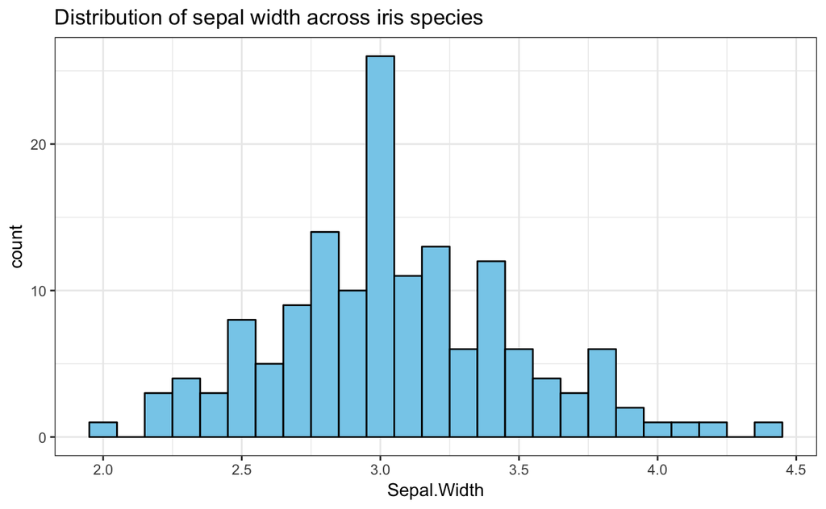

```r
## Graphical exploration: -----

## Distribution of 1 (continuous) variable:

# 3. Distribution of Sepal.Width across species:
ggplot(ir, aes(x = Sepal.Width)) +
  geom_histogram(binwidth = .1, fill = "skyblue", color = "black") +
  labs(title = "Distribution of sepal width across iris species") +
  theme_bw()
```

4. Create a plot that shows the shape of the distribution of `Sepal.Width` values for each species.

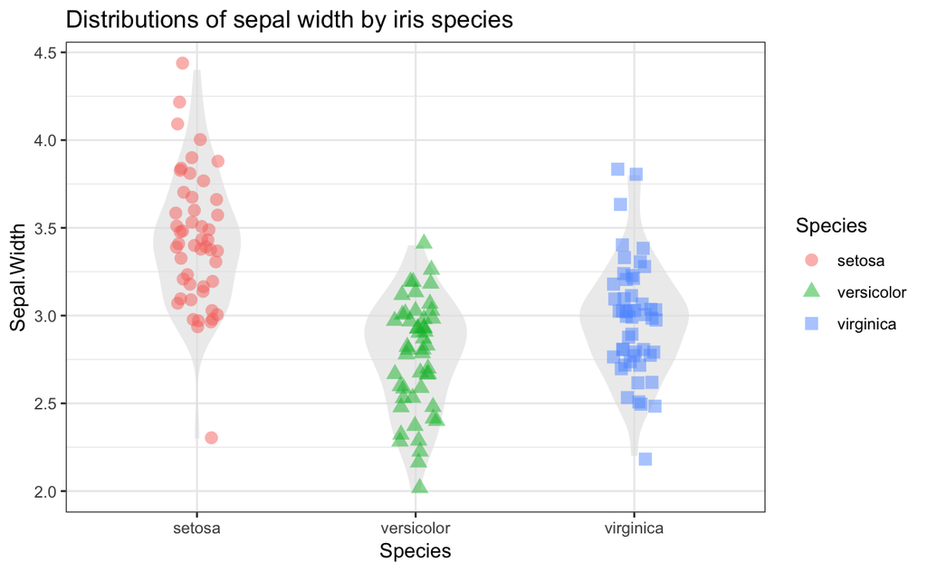

```r
## Distributions/relationships between 2 variables (1 categorical, 1 continuous):

## 4. The distributions of Sepal.Width by species:
ggplot(ir, aes(x = Species, y = Sepal.Width)) +
  geom_violin(fill = "grey90", linetype = 0, alpha = 2/3, width = .5) +
  geom_jitter(aes(color = Species, shape = Species), size = 3, alpha = 1/2, width = .10) +
  labs(title = "Distributions of sepal width by iris species") +
  theme_bw()
```

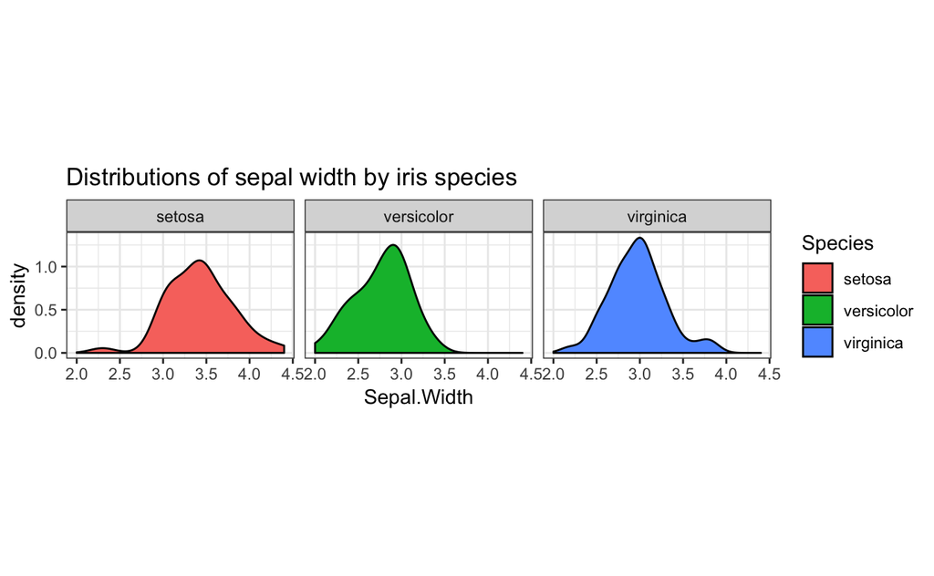

```r
## Alternative solution using density plots:
ggplot(ir, aes(x = Sepal.Width, fill = Species)) +
  facet_wrap(~Species) +
  geom_density() +
  labs(title = "Distributions of sepal width by iris species") +
  coord_fixed() +
  theme_bw()
```

5. Create a plot that shows `Petal.Width` as a function of `Sepal.Width` separately (i.e., in 3 facets) for each species.

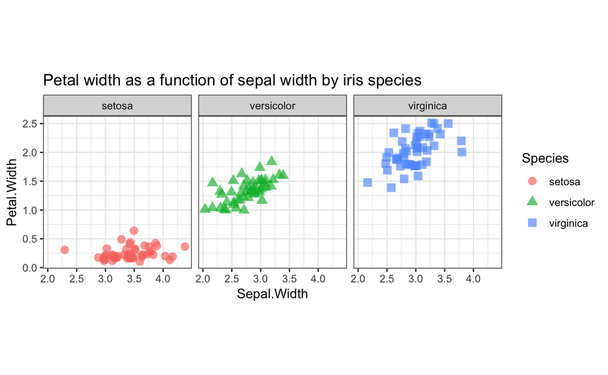

```r
## Relationships between 2 variables (2 continuous):

## 5. Petal.Width as a function of Sepal.Width by iris species:
ggplot(ir, aes(x = Sepal.Width, y = Petal.Width, color = Species, shape = Species)) +
  facet_wrap(~Species) +
  geom_jitter(size = 3, alpha = 2/3) +
  # geom_density2d() +
  coord_fixed() +
  labs(title = "Petal width as a function of sepal width by iris species") +
  theme_bw()
```

```r
## next step:
## Turn iris df into long format using tidyr::gather -----
## (see tidyr session)
```